# Cyclists_CaseStudy

Tsang Da Xin

2024-09-01

# Background

[figure not shown]

Cyclistic is a bike-based sharing company launched a successful bike-share offering since 2016 , the company has been relied on building general awareness and appealing to broad consumer segments. One approach that helped make these things possible was the flexibility of its pricing plans: single-ride passes, full-day passes, and annual memberships.

- Customers who purchase single-ride or full-day passes are referred to as casual riders.
- Customers who purchase annual memberships are Cyclistic members.

Now , as a junior data analyst who was been working on the marketing analyst team . the financial analyst has approach you to identify trends using Cyclistic historical bike trip data as she believes maximizing the number of annual members will be the key to company growth.

# Ask

These are the three main business questions broken down that will guide the future marketing program: 1. How do annual members and casual riders use Cyclistic bikes differently? 2. Why would casual riders buy Cyclistic annual memberships? 3. How can Cyclistic use digital media to influence casual riders to become members?

In this report , we only focus on one objectives that is assigned to us : ” How can Cyclistic use digital media to influence casual riders to become members? ”

### Stakeholders

Identifying stakeholders is a essential step as we want to ensure that the outcome meet the expectation of those who have a vested interested in our key findings.

- Director of marketing
- Cyclistic’s executives
- Cyclistic’s marketing team

# Prepare

### Data sources

I will be using dataset from the year 2021 which consists of historical user data from past 12 months . The data has been made available by Motivate International Inc. [under this license](https://divvybikes.com/data-license-agreement)

# Process - cleaning and filtering

R program is used throughout the analysis due each excel files contain large amount of datasets and spreadsheet is unable to handle sheer amount of data.

### Step 1 - importing

First , lets install and load up the library of the packages you have installed.

```r
#Installing the packages
#install.packages('tidyverse')
#install.packages('janitor')
#install.packages('lubridate')

#Load up the packages
library(tidyverse)
```

```r
library(readr)
library(lubridate)
library(ggplot2)
library(dplyr)
library(sf)
library(scales)
library(readxl) #to read excel file
```

Then , we would need to import csv file into Rstudio , you could use either “read_csv” or “read_excel”. But in this case , lets use “read_excel”.

While you are importing it , make sure to check if the formatting is correct. (Eg: Column “rideable_type” is identify as INT instead of string).

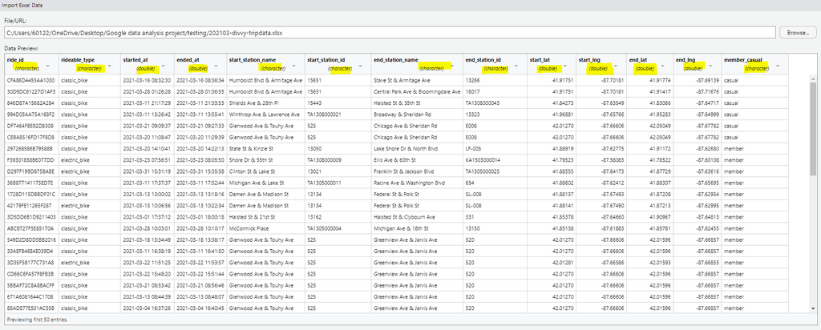

```r
Jan_tripdata <- read_excel("C:/Users/60122/OneDrive/Desktop/Google data analysis project/testing/202101-divvy-tripdata.xlsx")

Feb_tripdata <- read_excel("C:/Users/60122/OneDrive/Desktop/Google data analysis project/testing/202102-divvy-tripdata.xlsx")

March_tripdata <- read_excel("C:/Users/60122/OneDrive/Desktop/Google data analysis project/testing/202103-divvy-tripdata.xlsx")

April_tripdata <- read_excel("C:/Users/60122/OneDrive/Desktop/Google data analysis project/testing/202104-divvy-tripdata.xlsx")

May_tripdata <- read_excel("C:/Users/60122/OneDrive/Desktop/Google data analysis project/testing/202105-divvy-tripdata.xlsx")

June_tripdata <- read_excel("C:/Users/60122/OneDrive/Desktop/Google data analysis project/testing/202106-divvy-tripdata.xlsx")

July_tripdata <- read_excel("C:/Users/60122/OneDrive/Desktop/Google data analysis project/testing/202107-divvy-tripdata.xlsx")

Aug_tripdata <- read_excel("C:/Users/60122/OneDrive/Desktop/Google data analysis project/testing/202108-divvy-tripdata.xlsx")

Sep_tripdata <- read_excel("C:/Users/60122/OneDrive/Desktop/Google data analysis project/testing/202109-divvy-tripdata.xlsx")

Oct_tripdata <- read_excel("C:/Users/60122/OneDrive/Desktop/Google data analysis project/testing/202110-divvy-tripdata.xlsx")

Nov_tripdata <- read_excel("C:/Users/60122/OneDrive/Desktop/Google data analysis project/testing/202111-divvy-tripdata.xlsx")

Dec_tripdata <- read_excel("C:/Users/60122/OneDrive/Desktop/Google data analysis project/testing/202112-divvy-tripdata.xlsx")
```

Combine all monthly tables into one dataset using rbind function

```r
totaltrips <- rbind(Jan_tripdata , Feb_tripdata , March_tripdata , April_tripdata , May_tripdata , June_tripdata , July_tripdata , Aug_tripdata , Sep_tripdata , Oct_tripdata , Nov_tripdata , Dec_tripdata)
```

Then we use several function to inspect the columns for data integrity

```r
head(totaltrips)
```

```
## # A tibble: 6 × 13
##   ride_id          rideable_type started_at          ended_at
##   <chr>            <chr>         <dttm>              <dttm>
## 1 E19E6F1B8D4C42ED electric_bike 2021-01-23 16:14:19 2021-01-23 16:24:44
## 2 DC88F20C2C55F27F electric_bike 2021-01-27 18:43:08 2021-01-27 18:47:12
## 3 EC45C94683FE3F27 electric_bike 2021-01-21 22:35:54 2021-01-21 22:37:14
## 4 4FA453A75AE377DB electric_bike 2021-01-07 13:31:13 2021-01-07 13:42:55
## 5 BE5E8EB4E7263A0B electric_bike 2021-01-23 02:24:02 2021-01-23 02:24:45
## 6 5D8969F88C773979 electric_bike 2021-01-09 14:24:07 2021-01-09 15:17:54
## # ℹ 9 more variables: start_station_name <chr>, start_station_id <chr>,
## #   end_station_name <chr>, end_station_id <chr>, start_lat <dbl>,
## #   start_lng <dbl>, end_lat <dbl>, end_lng <dbl>, member_casual <chr>
```

```r
str(totaltrips)
```

```
## tibble [5,595,063 × 13] (S3: tbl_df/tbl/data.frame)
##  $ ride_id           : chr [1:5595063] "E19E6F1B8D4C42ED" "DC88F20C2C55F27F" "EC45C94683FE3F27" "4FA453A75AE377DB" ...
##  $ rideable_type     : chr [1:5595063] "electric_bike" "electric_bike" "electric_bike" "electric_bike" ...
##  $ started_at        : POSIXct[1:5595063], format: "2021-01-23 16:14:19" "2021-01-27 18:43:08" ...
##  $ ended_at          : POSIXct[1:5595063], format: "2021-01-23 16:24:44" "2021-01-27 18:47:12" ...
##  $ start_station_name: chr [1:5595063] "California Ave & Cortez St" "California Ave & Cortez St" "California Ave & Cortez St" "California Ave & Cortez St" ...
##  $ start_station_id  : chr [1:5595063] "17660" "17660" "17660" "17660" ...
##  $ end_station_name  : chr [1:5595063] NA NA NA NA ...
##  $ end_station_id    : chr [1:5595063] NA NA NA NA ...
##  $ start_lat         : num [1:5595063] 41.9 41.9 41.9 41.9 41.9 ...
##  $ start_lng         : num [1:5595063] -87.7 -87.7 -87.7 -87.7 -87.7 ...
##  $ end_lat           : num [1:5595063] 41.9 41.9 41.9 41.9 41.9 ...
##  $ end_lng           : num [1:5595063] -87.7 -87.7 -87.7 -87.7 -87.7 ...
##  $ member_casual     : chr [1:5595063] "member" "member" "member" "member" ...
```

```r
colnames(totaltrips)
```

```
##  [1] "ride_id"            "rideable_type"      "started_at"
##  [4] "ended_at"           "start_station_name" "start_station_id"
##  [7] "end_station_name"   "end_station_id"     "start_lat"
## [10] "start_lng"          "end_lat"            "end_lng"
## [13] "member_casual"
```

### Step 2 - cleaning / filtering

First , we remove the irrelevant columns that won’t be used

```r
totaltrips <- totaltrips %>% select(-c(start_lat,start_lng,end_lat,end_lng,start_station_id,end_station_id,end_station_name))
```

Then we clean the datasets with null values

```r
totaltrips <- na.omit(totaltrips) %>% distinct()
```

After removing row of data with null values , I have decided to remove any rows that contain “docked_bike” , as it does not provide a solid visualization to the problem statement . Thus , I classify them as dirty data.

```r
rideable_type <- totaltrips$rideable_type
totaltrips <- subset(totaltrips , rideable_type != "docked_bike")
```

Again , we review the datasets to check for consistency

```r
str(totaltrips)
```

```
## tibble [4,591,911 × 6] (S3: tbl_df/tbl/data.frame)
##  $ ride_id           : chr [1:4591911] "E19E6F1B8D4C42ED" "DC88F20C2C55F27F" "EC45C94683FE3F27" "4FA453A75AE377DB" ...
##  $ rideable_type     : chr [1:4591911] "electric_bike" "electric_bike" "electric_bike" "electric_bike" ...
##  $ started_at        : POSIXct[1:4591911], format: "2021-01-23 16:14:19" "2021-01-27 18:43:08" ...
##  $ ended_at          : POSIXct[1:4591911], format: "2021-01-23 16:24:44" "2021-01-27 18:47:12" ...
##  $ start_station_name: chr [1:4591911] "California Ave & Cortez St" "California Ave & Cortez St" "California Ave & Cortez St" "California Ave & Cortez St" ...
##  $ member_casual     : chr [1:4591911] "member" "member" "member" "member" ...
##  - attr(*, "na.action")= 'omit' Named int [1:690809] 10167 10168 10170 10171 10172 10173 10987 10991 10996 10997 ...
##   ..- attr(*, "names")= chr [1:690809] "10167" "10168" "10170" "10171" ...
```

Next, we added new columns “ride_length” , “day_of_week” and “month” .

```r
totaltrips <- totaltrips %>%                                                                                            mutate(ride_length = difftime(ended_at,started_at,units="mins")) %>%                                                  mutate(day_of_week = wday(totaltrips$started_at)) %>%                                                                 mutate(month = format(as.Date(totaltrips$started_at,format="%d/%m/%Y"),"%m"))
```

### Step 3 - Analyze

Now , its time to analyze our data. But before we do that , lets create some additional variables for ease of calculations in the future

```r
ride_length <- totaltrips$ride_length
member_casual <- totaltrips$member_casual
day_of_week <- totaltrips$day_of_week
rideable_type <- totaltrips$rideable_type
```

The code chunks below shows the step on calculating average ride length for each month of the year

```r
totaltrips %>% group_by(month,member_casual) %>% summarize(mean_ridelength = mean(ride_length)) %>% arrange(member_casual) %>% print(n=24) #display up to 24 rows of data
```

```
## # A tibble: 24 × 3
## # Groups:   month [12]
##    month member_casual mean_ridelength
##    <chr> <chr>         <drtn>
##  1 01    casual        20.62135 mins
##  2 02    casual        35.11794 mins
##  3 03    casual        28.89385 mins
##  4 04    casual        28.77257 mins
##  5 05    casual        29.54601 mins
##  6 06    casual        28.11505 mins
##  7 07    casual        26.48611 mins
##  8 08    casual        25.69609 mins
##  9 09    casual        24.77236 mins
## 10 10    casual        23.09008 mins
## 11 11    casual        19.67964 mins
## 12 12    casual        19.86508 mins
## 13 01    member        12.97413 mins
## 14 02    member        18.41053 mins
## 15 03    member        13.98886 mins
## 16 04    member        14.70024 mins
## 17 05    member        14.75050 mins
## 18 06    member        14.69884 mins
## 19 07    member        14.20671 mins
## 20 08    member        13.99501 mins
## 21 09    member        13.64451 mins
## 22 10    member        12.60073 mins
## 23 11    member        11.55059 mins
## 24 12    member        11.12541 mins
```

Then we went on to calculate average ride length for each day of the week

```r
totaltrips %>% group_by(day_of_week, member_casual) %>% summarize(mean_ridelength = mean(ride_length)) %>% arrange(member_casual)
```

```
## # A tibble: 14 × 3
## # Groups:   day_of_week [7]
##    day_of_week member_casual mean_ridelength
##          <dbl> <chr>         <drtn>
##  1           1 casual        30.00925 mins
##  2           2 casual        26.32965 mins
##  3           3 casual        23.43790 mins
##  4           4 casual        22.68285 mins
##  5           5 casual        22.85220 mins
##  6           6 casual        24.46281 mins
##  7           7 casual        28.23401 mins
##  8           1 member        15.80425 mins
##  9           2 member        13.33517 mins
## 10           3 member        12.84296 mins
## 11           4 member        12.86155 mins
## 12           5 member        12.83994 mins
## 13           6 member        13.36594 mins
## 14           7 member        15.40425 mins
```

Next , we calculate total amount of rides by month

```r
totaltrips %>% group_by(month , member_casual) %>% summarize(total_rides = n()) %>% arrange(member_casual) %>% print(n=24)
```

```
## # A tibble: 24 × 3
## # Groups:   month [12]
##    month member_casual total_rides
##    <chr> <chr>               <int>
##  1 01    casual              13811
##  2 02    casual               7948
##  3 03    casual              63211
##  4 04    casual             101467
##  5 05    casual             187825
##  6 06    casual             276118
##  7 07    casual             336774
##  8 08    casual             320321
##  9 09    casual             280825
## 10 10    casual             188425
## 11 11    casual              74264
## 12 12    casual              47988
## 13 01    member              72292
## 14 02    member              36357
## 15 03    member             134780
## 16 04    member             184993
## 17 05    member             246711
## 18 06    member             321668
## 19 07    member             340675
## 20 08    member             350508
## 21 09    member             346872
## 22 10    member             311707
## 23 11    member             202810
## 24 12    member             143561
```

Calculate total ride per day of the week

```r
totaltrips %>% group_by (day_of_week , member_casual) %>% summarize(total_rides = n()) %>% arrange(member_casual)
```

```
## # A tibble: 14 × 3
## # Groups:   day_of_week [7]
##    day_of_week member_casual total_rides
##          <dbl> <chr>               <int>
##  1           1 casual             359838
##  2           2 casual             211787
##  3           3 casual             205326
##  4           4 casual             211174
##  5           5 casual             217421
##  6           6 casual             272771
##  7           7 casual             420660
##  8           1 member             329961
##  9           2 member             366336
## 10           3 member             410610
## 11           4 member             420896
## 12           5 member             396137
## 13           6 member             389488
## 14           7 member             379506
```

We also want to calculate the max , min and median to get a better sense of the data layout

```r
#in order to get summary statistic of data by group
aggregate(totaltrips$ride_length ~ totaltrips$member_casual, FUN = max)
```

```
##   totaltrips$member_casual totaltrips$ride_length
## 1                   casual          1559.933 mins
## 2                   member          1559.933 mins
```

```r
aggregate(totaltrips$ride_length ~ totaltrips$member_casual, FUN = min)
```

```
##   totaltrips$member_casual totaltrips$ride_length
## 1                   casual         -58.03333 mins
## 2                   member         -54.08333 mins
```

```r
aggregate(totaltrips$ride_length ~ totaltrips$member_casual, FUN = median)
```

```
##   totaltrips$member_casual totaltrips$ride_length
## 1                   casual              15.0 mins
## 2                   member               9.8 mins
```

# Share

Now , lets visualize the data we have just analyze by using “ggplot” packages. In order to answer our business objective, lets to plot a few of our observations revolving around to remind ourselves on the business task:

**! Note that these are based on classic_bike and electric_bike !**

- Total rides between casual and annual members (monthly and weekly)
- Average rides between casual and annual members (monthly and weekly)
- How do casual and members use their bikes differently throughout the month and week
- Average different bike ride length throughout the month and week

#### Visualization 1

First visualization that we are performing is **“total ride per month”** and **“total rides per week”**

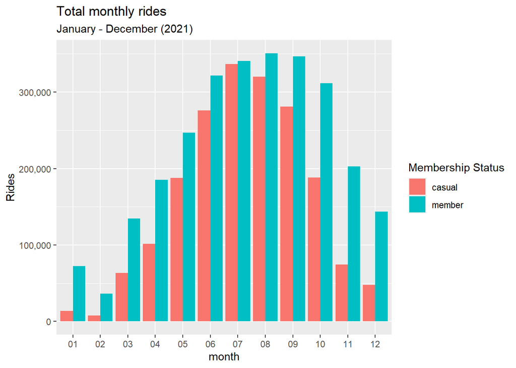

```r
ggplot(data = totaltrips) + geom_bar(mapping = aes(x = month , fill = member_casual), position = "dodge") + scale_y_continuous(labels=comma) + ggtitle("Total monthly rides") + labs(x = "month" , y="Rides" , fill="Membership Status" , subtitle = paste0("January - December (2021)"))
```

- The bar graph shows a pattern of seasonal fluctuations with bike rides , monthly ride for casual riders peak during spring and summer and dipping during winter period.

[figure not shown]

```r
ggplot(data = totaltrips) + geom_bar(mapping = aes(x = day_of_week , fill = member_casual), position = "dodge") + scale_y_continuous(labels=comma) + scale_x_continuous(breaks=seq(1,7,1))  + ggtitle("Total rides in a week") + labs(x = "Weekday" , y="Rides" , fill="Membership Status" , subtitle = paste0("Monday - Sunday (2021)"))
```

#### Visualization 2

Second visualization we will be doing is **“average ride per month”** and **“average ride per week”**

```
## Defaulting to continuous.
```

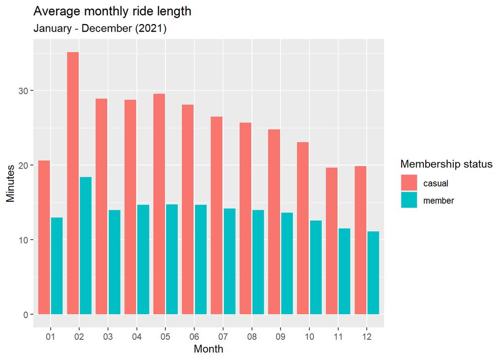

```r
totaltrips %>% group_by(month,member_casual) %>% summarize(mean_ridelength = mean(ride_length)) %>% ggplot(aes(x= month , y = mean_ridelength , fill = member_casual)) + geom_col(position="dodge2")+ ggtitle("Average monthly ride length") + labs(x="Month" , y="Minutes" , fill="Membership status" , subtitle = paste0("January - December (2021)"))
```

- As for average monthly ride length , it shows that casual riders has higher ride length than member throughout the year.Its highly speculate that casual riders may have use “full-day” passes.

```
## Defaulting to continuous.
```

[figure not shown]

```r
totaltrips %>% group_by(day_of_week,member_casual) %>% summarize(mean_ridelength = mean(ride_length)) %>% ggplot(aes(x= day_of_week , y = mean_ridelength , fill = member_casual)) + scale_x_continuous(breaks = seq(1,7,1)) + geom_col(position="dodge2")+ ggtitle("Average weekly ride length") + labs(x="Weekdays" , y="Minutes" , fill="Membership status" , subtitle = paste0("Monday to Sunday (2021)") )
```

- The same thing goes for day in the week , casual riders has higher ride time than members.

#### Visualization 3

It also essential to visualize the different type of bike riders as they may have different bike riding patterns.

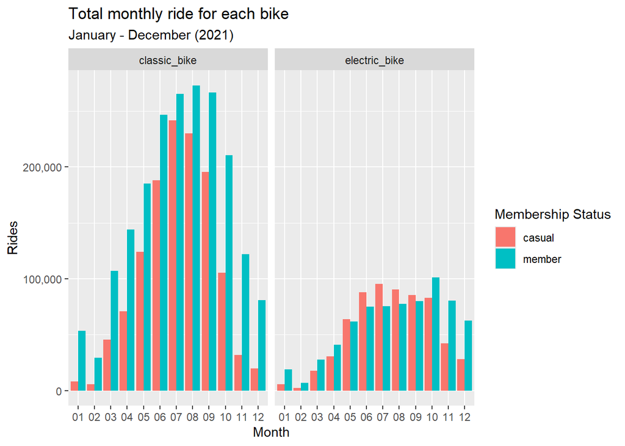

```r
ggplot(data= totaltrips) + geom_bar(mapping = aes(x = month , fill = member_casual) , position = "dodge") + scale_y_continuous(labels=comma) + ggtitle("Total monthly ride for each bike") + facet_wrap(~rideable_type) + labs(x="Month",y="Rides" , fill = "Membership Status" , subtitle = paste0("January - December (2021)"))
```

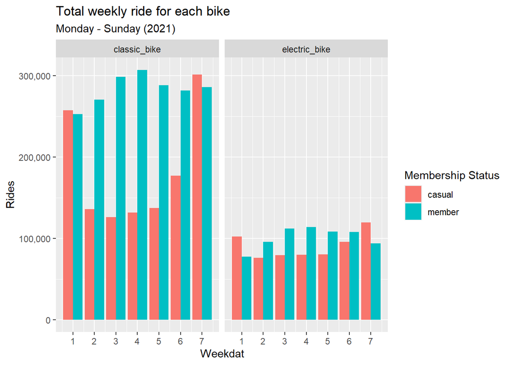

```r
ggplot(data= totaltrips) + geom_bar(mapping = aes(x = day_of_week , fill = member_casual) , position = "dodge") + scale_y_continuous(labels=comma) + scale_x_continuous(breaks = (seq(1,7,1))) + ggtitle("Total weekly ride for each bike") + facet_wrap(~rideable_type) + labs(x="Weekdat",y="Rides" , fill = "Membership Status" , subtitle = paste0("Monday - Sunday (2021)"))
```

- As for weekly rides , graph outline that riders favor more classic bike than electric bike . For both rides , member take more rides during weekday and casual riders takes more during weekend.

#### Visualization 4

Last but not least , lets visualize the average ride length throughout the month and week

```
## Defaulting to continuous.
```

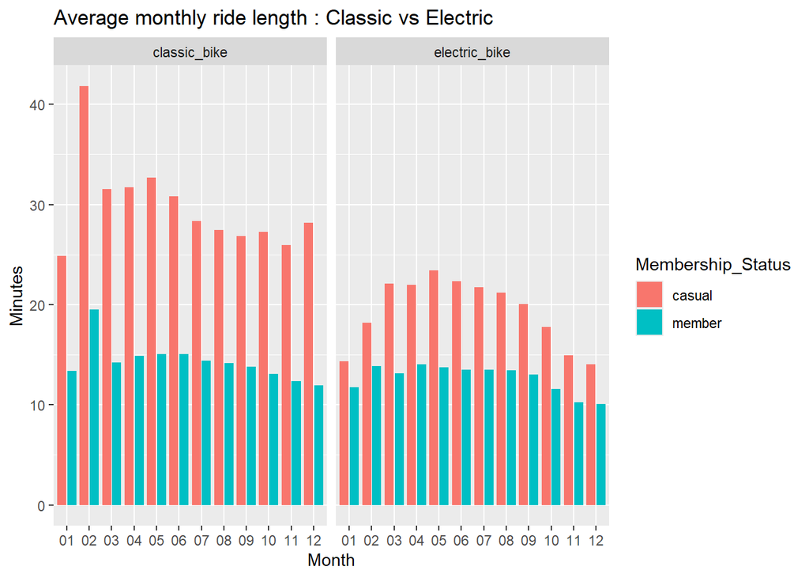

```r
totaltrips %>% group_by(month,member_casual, rideable_type) %>% summarize(mean_ridelength = mean(ride_length)) %>% ggplot(mapping = aes(x=month , y = mean_ridelength, fill = member_casual)) + geom_col(position = "dodge2") + ggtitle("Average monthly ride length : Classic vs Electric") + labs(x="Month" , y ="Minutes" , fill = "Membership_Status") + facet_wrap(~rideable_type)
```

- Even though average ride length of classic bike is still higher than electric bike , both graph highlight that casual riders has higher average ride length than member riders. It has a huge difference as casuals spend more time using the service than member riders.

```
## Defaulting to continuous.
```

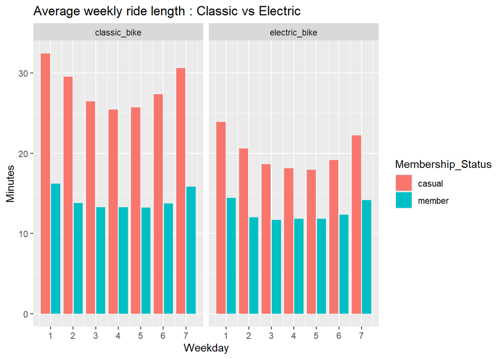

```r
totaltrips %>% group_by(day_of_week,member_casual, rideable_type) %>% summarize(mean_ridelength = mean(ride_length)) %>% ggplot(mapping = aes(x=day_of_week , y = mean_ridelength, fill = member_casual)) + scale_x_continuous(breaks =  seq(1,7,1))    + geom_col(position = "dodge2") + ggtitle("Average weekly ride length : Classic vs Electric") + labs(x="Weekday" , y ="Minutes" , fill = "Membership_Status") + facet_wrap(~rideable_type)
```

- As for weekly ride , its the same observation as-well.

# Act

### Key takeaways

- Casual riders is more actively during spring and summer season but less active during the winter season.
- Member riders tend to take more rides during the weekday , whereas casual riders take more rides on the weekend.
- In terms of bike comparison , graph shows that casual riders that use classic bikes contributes significantly to total ride length and average ride length.

### Recomendation

Now that we have finished creating visualizations , here are some recommendations that aimed at converting casual riders to annual members :

- Marketing campaigns can be conducted during spring and summer season as there high number of casual riders during that period.
- Restrict the amount of time that casual riders is able to ride and if they went pass that time , the system would automatically charge them extra. As for member riders , offer unlimited ride length which will convince casual riders to join membership.
- Cyclists can host exclusive events or group rides for members and they can earn points from it , which fostering a sense of community and belonging . In the meantime , member riders can share their status just like running app “Strava” . The points that they earned can redeemed reward like free rides or merchandise .